# Applied Time Series

This notebook is aimed to help me and maybe you understand topics of filtering and Bayesian methods in time series better. The notebook is done in an R kernel with the aim of creating much nicer visuals than would be possible in Python with good time series data. This notebook will be a bit of an oddball as I hope to synthesize both technical exercises and details with applications as this topic is very pertinent for data scientists, quants, and everyone (hello Covid data). Let me start with a very brief review of some fundamental concepts in time series and then start looking at our dataset.

```r
# library imports
packages <- c('corrplot',
              'forecast',
              'lubridate',
              'tidyverse',
              'Quandl')
new.packages <- packages[!(packages %in% installed.packages()[, 'Package'])]
if(length(new.packages)) {
  install.packages(new.packages)
}
lapply(packages, require, character.only = TRUE)
```

1. TRUE

2. TRUE

3. TRUE

4. TRUE

5. TRUE

# Key Concepts and Introduction

The backbone of nearly all time series models are the concept of difference equations so make sure you understand these very well and go through the examples I have and maybe the ones in a reference book posted below.

## Definitions

### Linear Difference Equation

An $N$th order linear difference equation is a recursive function of the form

$$y_{t}= \alpha_1 y_{t-1} + \alpha_2 y_{t-2}+\cdots +\alpha_N y_{t-N}+\epsilon_t$$

where $\alpha_1,\dots,\alpha_N$ are constants and $\epsilon_t$ could be thought of as an intercept.

### Stochastic Process

Given a probability triple $(\Omega, \mathcal{F},\mathbb{P})$ and a measurable space $(S,\Sigma)$, a stochastic process is a collection of $S$-valued random variables i.e. the set $\{X(t):t\in \tau\}$ where $\tau$ is usually representative of time in the form of integers or reals. Basically, it's just a collection of random variables defined on the same space indexed by $t$.

### Time Series Model

A time series model for an observed sequence of data $\{x_t\}$ is a specification of the joint distributions of a stochastic process $\{X_t\}$ where we postulate that $\{x_t\}$ is a realization of this process. In order words, a time series model simply tries to characterize the dynamics of the observed data by understanding the stochastic process believed to represent the data.

A specification of the joint distributions could be explicitly all possible joint distributions (combinations) for data say $x_1,\dots,x_n$. However this incorporates way too many parameters to estimate and so instead, we can look at the first few moments of the joint distribution we believe the process to follow. In the case of normal, we only need the first two moments as all others are zero!

### Autocovariance Function

The autocovariance function of a stochastic process is a mapping from the lag of a time series to the covariance of two terms in the series. More formally, for a series $\{X_t\}_{t\in\tau}$, we have that

$$\gamma(k)=Cov(X_t,X_{t-k}).$$

This is well-defined if the series is stationary which I will define below. The autocovariance is an intuitive way of capturing the relation of the random variables across the index. i.i.d noise has autocovariance of zero for all $t$ however, we could have a stochastic process that builds off the other as in the difference equations (examples below).

### Autocorrelation Function

Same setup as for the autocovariance, but instead we have

$$\rho(k)=Cor(X_t,X_{t-k}).$$

Generally, we care for the autocorrelation function as it's standardized and makes comparison of different models and data points easier.

### Partial Autocorrelation Function

pg 94 from brockwell & davis

### Weakly Stationary

We say that a stochastic process $\{X_t\}_{t\in\tau}$ is weakly stationary provided

**1.** $\mathbb{E}(X_t)=\mu$ for all $t$ (constant mean) **2.** $\mathbb{E}(X_t-\mu)(X_{t-k}-\mu)=\gamma(k)$ for all $t$ and any $k$ (covariance only depends on length $k$, not position $t$)

### Strict Stationary

We say a stochastic process $\{X_t\}_{t\in\tau}$ is strictly stationary provided that the joint distribution of $(X_{t-k},\dots,X_t)$ only depends on $k$ (the length) and not the exact position $t$. This is similar to the latter requirement for weak stationarity except this is imposed for a distribution which means that all moments depend on the length only whereas weak stationarity only requires the second moment to be invariant over the index $t$.

### MA(q) Process

pg 50 hamilton

### AR(p) Process

pg 58 hamilton

### ARMA(p,q) Process

pg 83 brockwell & davis

### ARIMA(p, d, q) Process

pg 180 brockwell & davis

### Causality

pg 242 brockwell & davis

### Invertibility

pg 64 hamilton

### Periodogram

pg 123 brockwell & davis

## Examples

#### First Order Example

Let us consider a spoiled kid who each year receives $\$10,000$ from his parents to gamble with at the local casino on games that cost $\$1$. For simplicity and really in reality, assume that the kid cannot gain any money from the games (greedy/rigged casino), and his wealth is monotonically decreasing where the odds of him keeping his $\$1$ after each game is $40\%$. Assume that the number of games the kid plays each year is exactly whatever his wealth or amount of money left over the prior year ($\$20,000=20,000$ games).

What would the kid's wealth look like in the long run?

This is a first-order difference equation where his wealth the subsequent year is a linear combination of his luck and his parents redistributing wealth again. That is

$$W_t=0.4\times W_{t-1} + 10,000.$$

Notice that

$$\lim\limits_{t\rightarrow\infty} W_t=0.4(0.4W_{t-2}+10,000)+10,000=0.4^2\times W_{t-2}+0.4\times 10,000+0.4^0\times 10,000$$

$$=\cdots =\lim\limits_{t\rightarrow\infty}\sum\limits_{i=0}^{t-1} 10,000\times 0.4^i.$$

Remember that this is simply a geometric series! Then in our case, the kid in the long run should expect to accumulate

$$ \frac{\$10,000}{1-0.4}\approx \$16,667$$

and so the kid shouldn't go broke, but if he wasn't so degenerate that would be $\lim\limits_{t\rightarrow\infty}\$10,000^t\rightarrow\infty$ if he was immortal haha. Importantly, notice that the difference equation, as a geometric series, is unbounded, unstable, or infinite if the constant we multiply the series by iteratively is not less than 1. Infinite wealth is given to the kid if the probability of winning is 1 each time!

#### Nth Order Example

Now let us assume we have an intelligent spoiled brat. He throws all his wealth from the time prior into the games where the probability of winning the dollar back is still 0.4, but like in Ocean's 11, he knows the system he's playing. That is, the machine has a $20\%$ chance of leaving his wealth two peiods prior in the slot for him to grab. Additionally, his wealth three periods prior gets taken by the accountant in some duffle bag that has a $20\%$ chance of falling out when he carries it to the boss. Finally, the kid realizes that his wealth four periods prior is exchanged for bitcoin by the boss where he can mine and obtain $50\%$ of it back because they don't know how to code like he does. What does the kid's long-term dynamics look like now?

This will still be a diffference equation, but a bit more interesting as we have prior periods of wealth integrated into his wealth at time $t$ that is given by

$$W_t=0.4W_{t-1}+0.2W_{t-2}+0.2W_{t-3}+0.5W_{t-4}+10,000.$$

However as you can see recursive substitution to get a geometric series as we did before proves to be much, much more tricky. It is possible, but rather we can represent the $4$th-order difference equation as a first-order difference equation by using what is known as **state-space form**. Notably, define

$$F=\begin{bmatrix}0.4&0.2&0.2&0.5\\1&0&0&0\\0&1&0&0\\0&0&1&0\end{bmatrix},$$

$$x_t=\begin{bmatrix} w_{t}\\w_{t-1}\\w_{t-2}\\w_{t-3}\end{bmatrix},$$

and

$$z=\begin{bmatrix} 10,000\\0\\0\\0\end{bmatrix}.$$

Then notice that $x_t=Fx_{t-1}+z_t$! It expresses our system equivalently in state-space form - basically writing the system in matrix notation is a more accurate way of describing it. Then we have recursively that

$$\lim\limits_{t\rightarrow\infty} x_t=F(Fx_{t-2}+z)+z=\cdots =\lim\limits_{t\rightarrow\infty}\sum\limits_{i=0}^t F^i z.$$

Now if $F$ has $N$ (or 4 in our case) distinct roots, then we can diagonalize the matrix so that

$$F=TDT^{-1}$$

where $D$ is the diagonal matrix of eigenvalues $\lambda_1,\dots,\lambda_4$ and $T$ consists of the corresponding eigenvectors. Then we have that $F^t=TD^t T^{-1}$. For our system $F$, we find the eigenvalues and eigenvectors using `eigen()` from R below

```r
F <- matrix(c(0.4, 0.2, 0.2, 0.5,
              1.0, 0.0, 0.0, 0.0,
              0.0, 1.0, 0.0, 0.0,
              0.0, 0.0, 1.0, 0.0),
            nrow = 4, ncol = 4, byrow = TRUE)
eigen(F)
```

```
eigen() decomposition
$values
[1]  1.1092230+0.0000000i  0.0152887+0.7804318i  0.0152887-0.7804318i
[4] -0.7398004+0.0000000i

$vectors
             [,1]                  [,2]                  [,3]          [,4]
[1,] 0.5763683+0i  0.0188030+0.3196141i  0.0188030-0.3196141i  0.2855358+0i
[2,] 0.5196145+0i  0.4098496-0.0160641i  0.4098496+0.0160641i -0.3859633+0i
[3,] 0.4684491+0i -0.0102918-0.5253590i -0.0102918+0.5253590i  0.5217127+0i
[4,] 0.4223219+0i -0.6731646+0.0000000i -0.6731646+0.0000000i -0.7052074+0i
```

These eigenvalues are distinct and so we can in fact diagonalize the matrix. One of the eigenvalues is not less than one! What this means is that in the long run, $F^t=TD^tT^{-1}$ will have some issues as $1.1^t$ limits to infinity. Our boy finally understands how the market works and will have infinite wealth if he keeps his edge on the casino!

Now that is dandy and all for the spoiled kid that he will achieve god-like status in infinite time, but what if the eigenvalues were all less than 1 in modulus (absolute value) - pretend the first eigenvalue was 0.5 instead of 1.109. Then to find the limiting value of $w_t$, we know that this is the first entry in the vector $x_t$ and so we are interested in the first entry in the vector $(TD^tT^{-1})z$ as $z$ is nonzero in the first entry and zero everywhere else.

$$(TD^tT^{-1})_{11}=\sum\limits_{i=1}^4 T_{1i}\lambda_i^tT_{i1}^{-1}.$$

Finding $T$ exactly is actually fairly straightforward and derived in the appendix of Time Series Analysis by Hamilton. Notably, we get that the above becomes

$$\sum\limits_{i=1}^4 T_{1i}\lambda_i^tT_{i1}^{-1}=\sum\limits_{i=1}^4 \frac{\lambda_i^{4-1}}{\prod\limits_{k=1,k\neq i}^4 (\lambda_i-\lambda_k)}\times\lambda_i^t.$$

Instead of being fancy like Hamilton, I resort to the simple minded calculator to do my job.

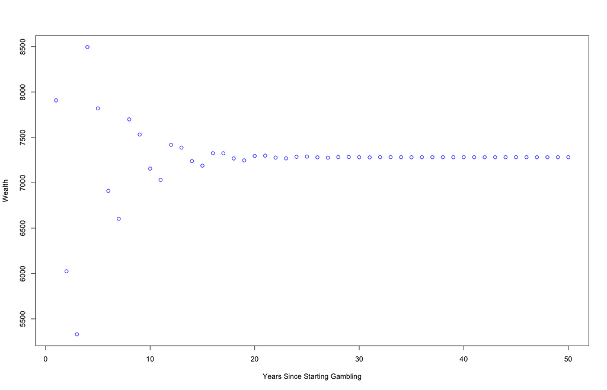

```r
eigenvalues <- eigen(F)$values
# changing the one that is greater than one to 0.5 as mentioned above
eigenvalues[1] <- 0.5

# function to return the T_1i * T_i1 entry
magnitude <- function (t) {
    terms <- c()
    for (eigenvalue in eigenvalues) {
        eigen_prod <- prod(eigenvalue - eigenvalues[! eigenvalues == eigenvalue])
        term <- eigenvalue ^ (3 + t) / eigen_prod
        terms <- c(terms, term)
    }
    return (sum(terms))
}

# now take geometric sum of terms
geom_sum <- function (k) {
    sum <- 10000
    for (i in 1:k) {
        sum <- sum + magnitude(i) * 10000
    }
    return (sum)
}

# plotting behavior of magnitude for varying k
geom_results <- lapply(1:50, geom_sum)
suppressWarnings(plot(x = 1:50,
                      y = geom_results,
                      xlab = 'Years Since Starting Gambling',
                      ylab = 'Wealth', col = 'blue'))
```

Huh, well the kid's wealth ends up stabilizing around $\$7,250$ - despite all eigenvalues in our shifted scenario, the kid doesn't end up homeless in a million years (assuming he doesn't have any expenses ;). This was a fun problem that hopefully gave you a taste for difference equations which essentially characterize the dynamics of the system over time. Notice that we only used non-random entries - all probabilities were given and not modified to express uncertainty. This was done as we are working in baby steps towards a more general form, but we can introduce random values and make this much more realistic.

If $F$ were not symmetric and contains repeating eigenvalues, the usual diagonalization above doesn't work. However, we can always obtain the **Jordan normal form** of a matrix. This form allows us to decompose a matrix as $F=TJT^{-1}$ where

$$J=\begin{bmatrix}\lambda_1&1&0&0\\0&\lambda_2&1&0\\0&0&\lambda_3&1\\0&0&0&\lambda_4\end{bmatrix}$$

consists of the eigenvalues $\lambda_1,\dots,\lambda_4$ and $T$ consists of the generalized eigenvectors where $TT^{-1}=I$. The theory behind Jordan normal forms and the like is a bit past the level I hope to achieve with this notebook, however, I recommend "Linear Algebra" by Hoffman and Kunze and have personal notes accompanying this book if you want (ask).

### Time Series Model Example - Gamma Noise

Consider the case where we believe that the stochastic process is to be independent and identically distributed Gamma(5,5) random variables. That is

$$P(X_t|X_1,\dots,X_{t-1})=P(X_t)$$

and $E(X_iX_j)=0$ for all $i\neq j$. Then the process looks like the following in simulation

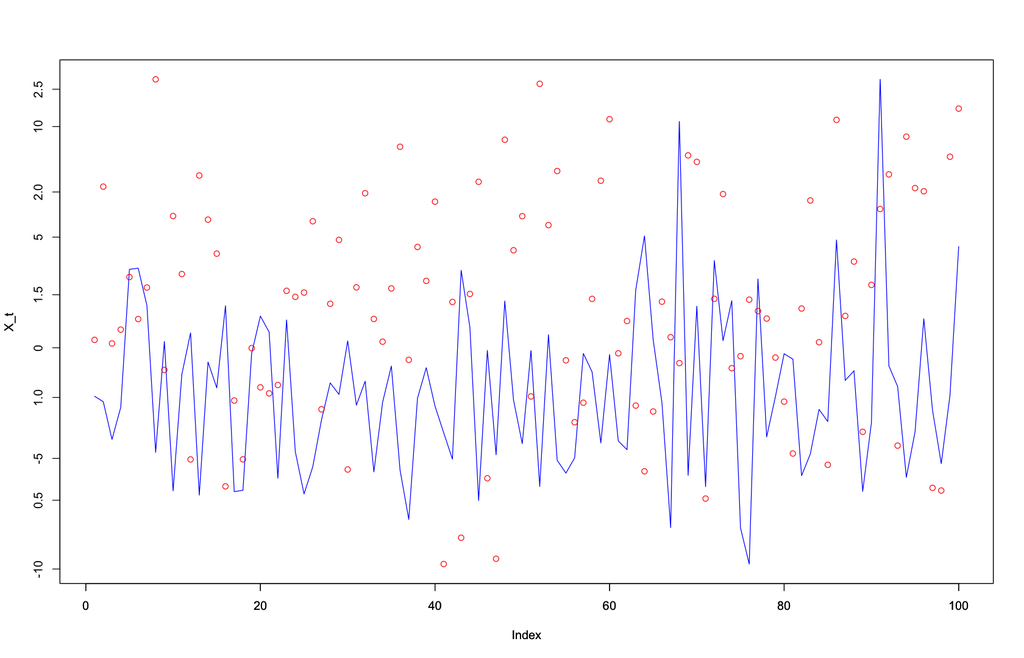

```r
# pretend data is actually a convolution w/ gamma(5,5) and normal(0,5)
our_data <- rgamma(100, 5, 5) + rnorm(100, 0, 5)

# our fitted model
realizations <- rgamma(100, 5, 5)
plot(realizations, col = 'blue', type = 'l', ylab = 'X_t')
par(new = TRUE)
plot(our_data, col = 'red', ylab = 'X_t')
```

The above example is very boring I know, but again the concept of i.i.d noise plays a very important role. In fact, our goal in modeling is generally to reduce a more complicated system down to i.i.d (white) noise after fitting a model. Why well - we assume each point is a random variable so there is inherent randomness irrespective of if we get the distribution right - if we assume randomness, then we cannot expect to remove that randomness is what I'm trying to say.

### Time Series Model - Trend and Seasonality

Next let us consider looking at Oil prices and concurring up some time series model for the evolution.

```r
oil_prices = Quandl('NSE/OIL')
```

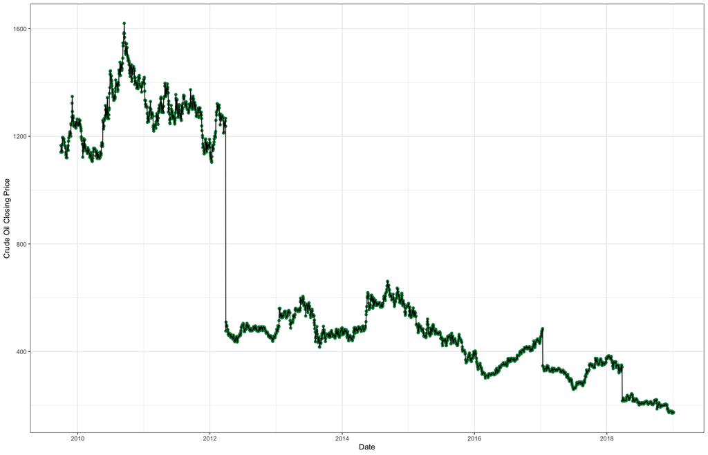

```r
ggplot(data = oil_prices, aes(x = Date, y = Close)) +
geom_point(color = 'springgreen4', size = 1.5) +
geom_line(color = 'black') +
labs(y = 'Crude Oil Closing Price') + theme_bw()
```

$$P_t=\alpha + \beta t + \epsilon_t$$

i.e. that oil is linear in time plus some Gaussian noise. Clearly this process does not satisfy the assumptions of OLS, but ignorance is bliss ;).

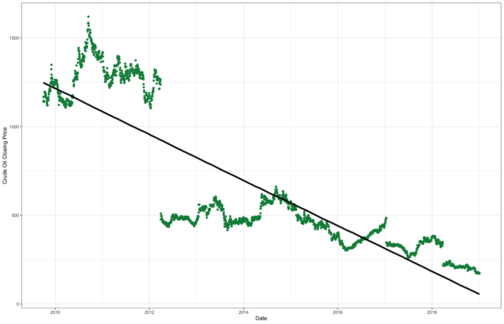

```r
X <- matrix(c(rep(1, nrow(oil_prices)),
              1:nrow(oil_prices)),
            nrow = nrow(oil_prices), ncol = 2)

# OLS solution
beta_hat <- solve(t(X) %*% X) %*% t(X) %*% oil_prices[, 'Close']
y_hat <- beta_hat[1] * X[, 1] + beta_hat[2] * X[, 2]
oil_prices[, 'Close Estimate'] <- y_hat

# plotting model fit
ggplot(data = oil_prices) +
geom_point(aes(x = Date, y = Close), color = 'springgreen4') +
geom_line(aes(x = Date, y = `Close Estimate`), size = 1.5) +
labs(y = 'Crude Oil Closing Price') + theme_bw()
```

Meh, we could do better with a point process model but that's besides the point (pun intended). There are seasonalities to oil which we could model by expressing the current oil price in terms of the oil price say 6 months ago if the seasonality is semi-annual, we could use sines and cosines (fourier series - in statistics world, including terms like $\alpha\cos(\beta t)$ is known as harmonic regression), etc.

The point of this example is really two-fold. In a parametric setting, your residuals are everything and they tell you if you did a good job or not and you can look at your residuals to notice any further patterns to take out and compound in some long equation. This is the premise of usual time-series analysis - take out the trend, look at residuals, take out seasonalities and cyclicalities, and analyze residuals to see if they look like white noise (if no, go back to drawing board). Finally, domain knowledge is the most important feature in being able to develop **stable** and useable models. I don't know crude oil as well as Ed Morse does (I go ask him - not look at residuals and overfit to unique events that will not happen again).

## Returning to the Application

The data set we will be working with is Texas county housing level data I scraped off of Texas A&M's website. The data was gathered in strings, so we had a little bit of cleaning to do.

```r
getData <- function(csv_loc) {
    # :param: csv_loc - string, texas county file paths
    # :return: df - dataframe, texas county data cleaned

    # reading in the csvs from the data folder
    df1 <- read.csv(paste(csv_loc, 'texas_counties1.csv', sep = '/'))
    df2 <- read.csv(paste(csv_loc, 'texas_counties2.csv', sep = '/'))
    df3 <- read.csv(paste(csv_loc, 'texas_counties3.csv', sep = '/'))

    # merging the csvs by the date column
    df <- rbind(df1, df2)
    df <- rbind(df, df3)

    # removing commas in price data
    comma_vars <- c('dollar_vol', 'avg_price', 'med_price')
    df[, comma_vars] <- sapply(df[, comma_vars],
                               function (x) as.numeric(gsub(',', '', x)))

    # changing dates to datetime objects
    df['date'] <- lapply(as.vector(df['date']),
                         function (x) as.Date(strptime(paste('01', x, sep = ''),
                                               '%d %b %Y')))

    # changing all price/listing columns to numeric
    numeric_cols <- c('sales', 'dollar_vol', 'avg_price', 'med_price',
                     'total_listings', 'month_inventory')
    df[, numeric_cols] <- sapply(df[, numeric_cols], as.numeric)

    # dropping the X column - accidental indexing
    df <- df[, names(df) != 'X']
}

df <- getData('data')
head(df)
```

A data.frame: 6 × 8

|  | date <date> | sales <dbl> | dollar_vol <dbl> | avg_price <dbl> | med_price <dbl> | total_listings <dbl> | month_inventory <dbl> | county <chr> |
| --- | --- | --- | --- | --- | --- | --- | --- | --- |
| 1 | 2011-01-01 | 15 | 1122600 | 74840 | 50000 | 344 | 31.0 | Anderson |
| 2 | 2011-02-01 | 20 | 1652300 | 82615 | 66950 | 371 | 30.1 | Anderson |
| 3 | 2011-03-01 | 25 | 3013550 | 120542 | 92000 | 372 | 27.1 | Anderson |
| 4 | 2011-04-01 | 25 | 2733350 | 109334 | 115000 | 365 | 24.1 | Anderson |
| 5 | 2011-05-01 | 27 | 2239161 | 82932 | 70000 | 387 | 23.8 | Anderson |
| 6 | 2011-06-01 | 21 | 1798605 | 85648 | 78000 | 421 | 23.9 | Anderson |

## About the Data and our Problem

Filtering and the problem of prediction in machine-learning go hand in hand. In this particular case, I believe our goal is to predict the average price column for the next quarter (3 months). This problem is tangible and relevant as if we can predict the average price for the next three months in a variety of Texas counties, then we have a great chance of being able to lever up and flip properties in the short-term picture - an interesting way of accruing wealth. Of course, this data set is simplified in the sense that I only include a few relevant variables - to spin this into your own personal project, consider adding macroeconomic variables that are indexed by quarter and month as well as more microeconomic variables like education level, companies in the city, average education level, etc!

Now first, it is sensible to perform some exploratory data analysis (EDA) to gain a sense of how exactly we should predict home prices (I will just cover filtering however).

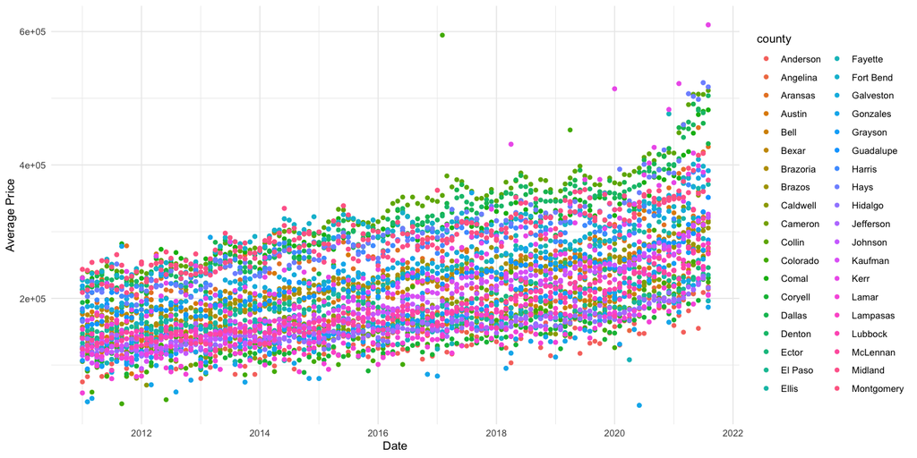

```r
options(repr.plot.width = 12, repr.plot.height = 6)
ggplot(data = df) +
geom_point(aes(x = date, y = avg_price, color = county)) +
labs(x = 'Date', y = 'Average Price') + theme_minimal()
```

There's a noticeable linear trend with respect to time of our county data. Another interesting aspect is the fairly large dispersion among counties for average price - there are a few outliers on the positive end (that point in 2017 from Colorado county) and a few on the positive and negative bands as we enter Covid where the housing dynamic across the nation experienced a phase change. As a side note, I would be curious if the time series has any cyclical bits - are home prices generally higher in the spring and come back down in the winter? Well, we plot that below and underwhelmingly there is very little change. If desirable, we could construct a hypothesis test of sorts to compare the data (a simple LRT or Wald test could suffice as data is sufficiently large).

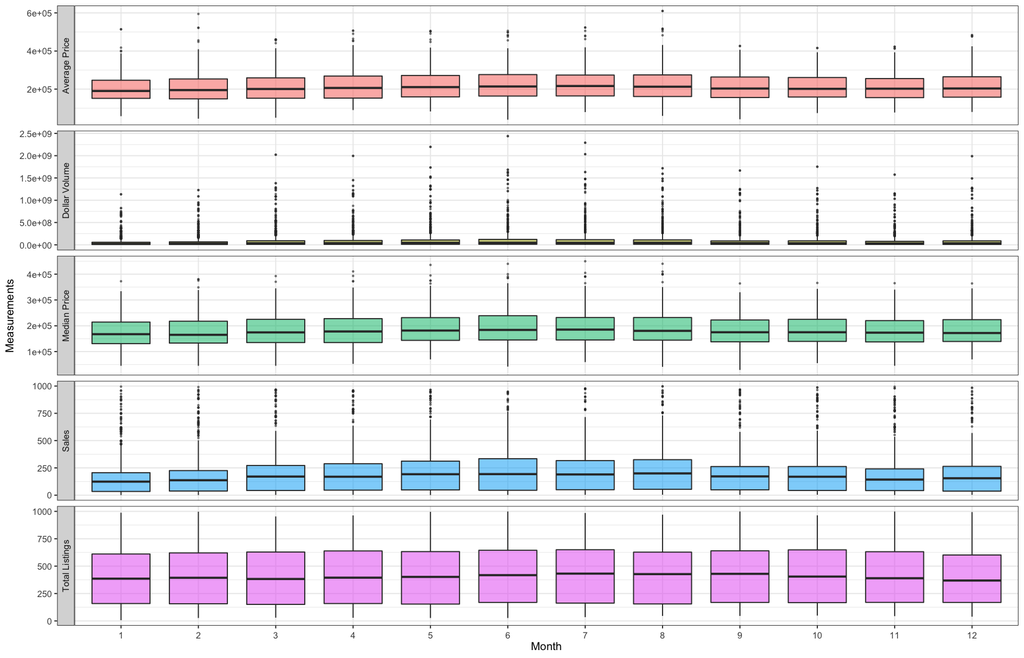

```r
options(repr.plot.width = 14, repr.plot.height = 9)
df %>%
    mutate(month = factor(month(date))) %>%
    select(sales, dollar_vol, avg_price, med_price, total_listings, month) %>%
    gather('type', 'value', -c('month')) %>%
    ggplot() +
    geom_boxplot(aes(x = month, y = value, group = month, fill = type, alpha = 0.7),
                 outlier.size = 0.5) +
    labs(x = 'Month', y = 'Measurements', fill = 'Date') +
    scale_color_manual(values = c('sales' = '#80B1D3',
                                  'dollar_vol' = '#8DD3C7',
                                  'avg_price' = '#FDB462',
                                  'med_price' = '#FB8072',
                                  'total_listings' = '')) +
  theme_bw() +
  theme(axis.text.x = element_text(angle = 0, vjust = 0.5),
        legend.position = 'None') +
  facet_grid(rows = vars(type),
             scales = 'free',
             switch = 'y',
             labeller = as_labeller(c(`sales` = 'Sales',
                                      `dollar_vol` = 'Dollar Volume',
                                      `avg_price` = 'Average Price',
                                      `med_price` = 'Median Price',
                                      `total_listings` = 'Total Listings')))
```

```r
summary(df)
```

```
      date                sales         dollar_vol          avg_price
 Min.   :2011-01-01   Min.   :  1.0   Min.   :4.500e+04   Min.   : 39667
 1st Qu.:2013-08-01   1st Qu.: 43.0   1st Qu.:9.848e+06   1st Qu.:156223
 Median :2016-04-01   Median :163.0   Median :3.590e+07   Median :204636
 Mean   :2016-04-14   Mean   :212.2   Mean   :1.241e+08   Mean   :215287
 3rd Qu.:2018-12-01   3rd Qu.:282.0   3rd Qu.:9.474e+07   3rd Qu.:263978
 Max.   :2021-08-01   Max.   :997.0   Max.   :2.439e+09   Max.   :610047
                      NA's   :866     NA's   :2           NA's   :2
   med_price      total_listings  month_inventory     county
 Min.   : 29000   Min.   :  7.0   Min.   : 0.300   Length:7290
 1st Qu.:138000   1st Qu.:162.0   1st Qu.: 2.500   Class :character
 Median :175000   Median :400.0   Median : 3.500   Mode  :character
 Mean   :184732   Mean   :416.3   Mean   : 4.372
 3rd Qu.:225574   3rd Qu.:631.0   3rd Qu.: 5.175
 Max.   :450000   Max.   :999.0   Max.   :31.000
 NA's   :2        NA's   :3899    NA's   :2160
```

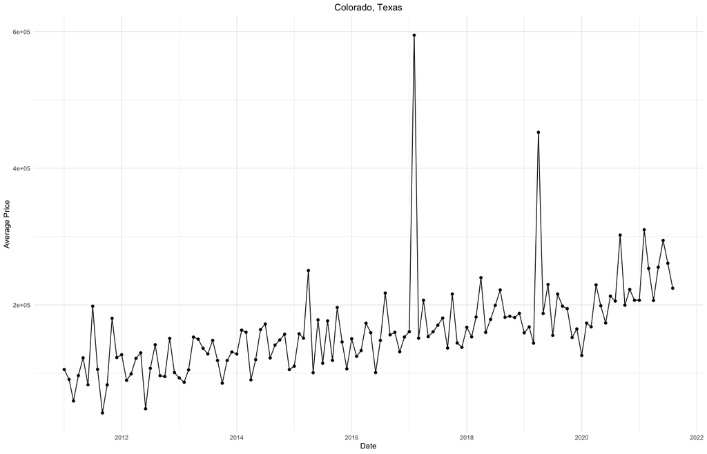

```r
# state with outliers - some ugly place without local government
ggplot(data = df %>% filter(county == 'Colorado'), aes(x = date, y = avg_price)) +
geom_point() +
geom_line() +
labs(x = 'Date', y = 'Average Price', title = 'Colorado, Texas') +
theme_minimal() +
theme(plot.title = element_text(hjust = 0.5))
```

This place is causing a rucus with the instability of prices - on the Wikapedia page, it says that this particular county is unincorporated - meaning that there is no local government. I think that could add some color as to why the prices here are pretty unstable over time. For filtering, I say we exclude this. Now time to pivot to the actual filtering and math...

# State Space Formulation

## Key Definitions & Theorems

### State Space Model:

- Definition 1 (Gelb): **rephrase this** My words: basically we have a $N$th order differential equation and we can write the system in matrix notation along with perturbations/noise/etc.
- Definition 1 (Chopin): A state-space model is a time series model that consists of two discrete stochastic processes $\{X_t\}=(X_t)_{t\geq 0}$ and $\{Y_t\}=(Y_t)_{t\geq 0}$ taking values in spaces $\mathcal{X}$ and $\mathcal{Y}$ respectively. (This is a very loose definition - not very mathematical).
- Definition 2 (Chopin): Let us consider again two sequences of random variables $(X_t)_{t\geq 0}$ and $(Y_t)_{t\geq 0}$ such that:

$$X_0 = K_0(U_0,\theta)$$

$$X_t = K_t(X_{t-1},U_t,\theta),\;\; t\geq 1$$

$$Y_t=H_t(X_t,V_t,\theta),\;\; t\geq 0$$

where $K_0$, $K_t$, $H_t$ are deterministic functions, and $\{U_t\}$, $\{V_t\}$ are sequences of i.i.d random variables.

### Example of State Space Models:

Here I would like to handpick some examples mentioned in the two books for state space models as well as work out a few problems from Gelb.

- Example 1: Physics
- Example 2: Periodic Random Walk

# Modelling Variance of Home Prices

With this in mind, we can go about modeling volatility of home prices in two classes I will cover. The first class assumes that there are many unobservable and unpredictable features from which we decidedly model volatility as a stochastic process. The second class of models coincides more in line with Bayesians where we understand certain market-regime shifts and update volatility in accordance with our beliefs - akin to change-point, Monte Carlo (Gibbs sampling in particular).

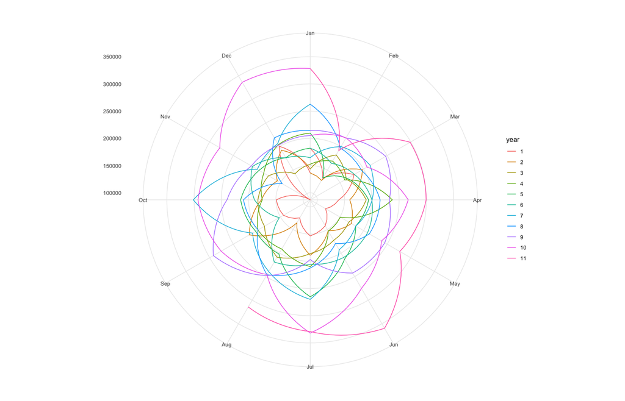

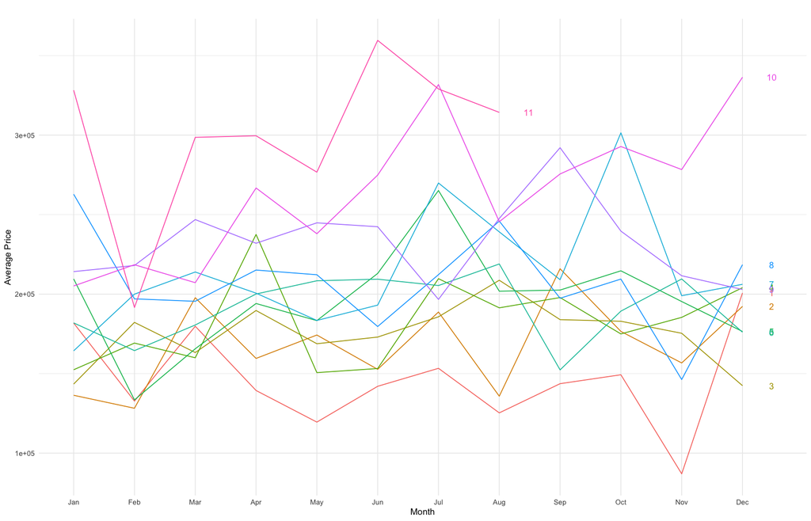

```r
# pulling out a county with a lot of variance
austin_prices <- df %>% filter(county == 'Austin') %>% select('avg_price')
austin_ts <- ts(austin_prices, frequency = 12)

# circular annual plot
ggseasonplot(austin_ts, polar = TRUE, main = '', xlab = '') +
theme_minimal()

# unstacked annual plot
ggseasonplot(austin_ts, year.labels = TRUE, main = '', ylab = 'Average Price') +
theme_minimal()
```

## Stochastic Volatility

A good data scientist will be able to blend intuition, expert opinions, and exploratory analysis of the data into a judgement call for the type of model that best suits the data. In our case, I believe that a stochastic volatility model for the entire class of counties is naive as some counties in Texas are much more agricultural while counties like Austin are experiencing inflows due to tech and finance alike. With that said, I think the latter class of models - Bayesian change-point models are much easier to justify to clients than this approach. However, the goal of this notebook is to survey these topics together so down the line, you may find this particular naive model more suitable for your problem.

For starters, we will consider the simplistic GARCH model. But first, let us introduce two concepts from stochastic processes that will provide us some insight into the innerworkings of the model.

### Martingale

- Definition 1: A stochastic process $\{S_t\}_{t\in\tau}$ is a **martingale** with respect to another stochastic process $\{X_t\}_{t\in\tau}$ if for all $t$, we have

**1)** $\mathbb{E}(|S_t|)<\infty$

**2)** $\mathbb{E}\left(|S_t||X_1,\dots,X_{t-1}\right)=S_{t-1}$

A martingale is a fair game - i.e. consider a sequence of tosses of the fair coin where we define $X_t$ to be binary where heads is assigned the value 1 and tails the value -1 and $S_t=\sum_1^t X_i$. Then clearly

$$\mathbb{E}(S_t)=\mathbb{E}\left(\sum\limits_{i=1}^t X_i\right)=\mathbb{E}(X_1)+\cdots +\mathbb{E}(X_{t-1})=0<\infty$$

and prior flips of the coin do not lend us intuition for the next roll, so the conditonal expectation is

$$\mathbb{E}\left(S_t|X_1,\dots,X_{t-1}\right)=\mathbb{E}\left(S_{t-1}+X_t\right)=S_{t-1}+\mathbb{E}(X_t)=S_{t-1}.$$

As a non-example of a martingale, consider rather the sequence of tosses where $X_t$ is assigned the value 1 for heads and 0 for tails. Then $\mathbb{E}(S_t)\nless\infty$ as it is binomial, so $np\rightarrow\infty$ as $n\rightarrow\infty$.

- Definition 2: A stochastic process $\{X_t\}_{t\in\tau}$ is a **martingale difference sequence** if for all $t$, we have that

**1)** $\mathbb{E}(X_t)<\infty$

**2)** $\mathbb{E}\left(X_t|X_1,\dots,X_{t-1}\right)=0$ almost surely

Any martingale can be turned into a martingale difference sequence if we define $Y_t=X_t-X_{t-1}$. Notice that the prior coinflip example could be an example if we let $D_t=S_t-S_{t-1}$ or we could also consider the coinflip stochastic process $\{X_t\}_{t\in\tau}$ as a martingale difference sequence without looking at the sum of heads and tails if our coin is fair, so $\mathbb{P}(\text{heads})=\frac{1}{2}$, as then $\mathbb{E}(X_t)=0$ and

$$\mathbb{E}\left(X_t|X_1,\dots,X_{t-1}\right)=\mathbb{E}(X_t)=0.$$

- Definition 3: A **GARCH(p, q) model** is a margingale difference sequence $\{Y_t\}_{t\in\tau}$ such that for all $t$, we have

$$y_t=\sigma_t\epsilon_t$$

where $\epsilon_t\sim\mathcal{N}(0,1)$ and

$$\sigma_t^2=a_0+\sum\limits_{i=1}^p a_i\sigma_{i}^2+\sum\limits_{j=1}^q b_j\epsilon_j^2$$

for a sequence of constants $a_0,\dots,a_p$ and $b_1,\dots,b_q$ from some field of numbers - i.e. the reals.

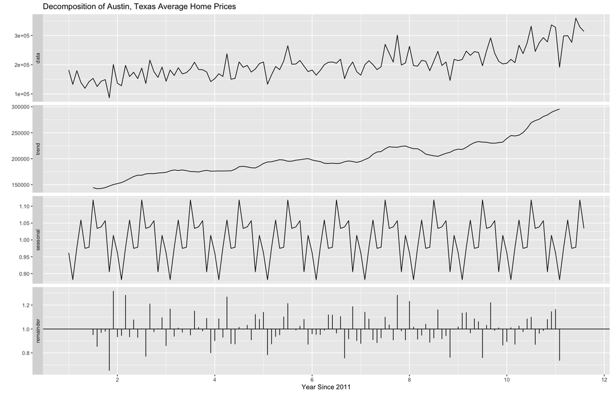

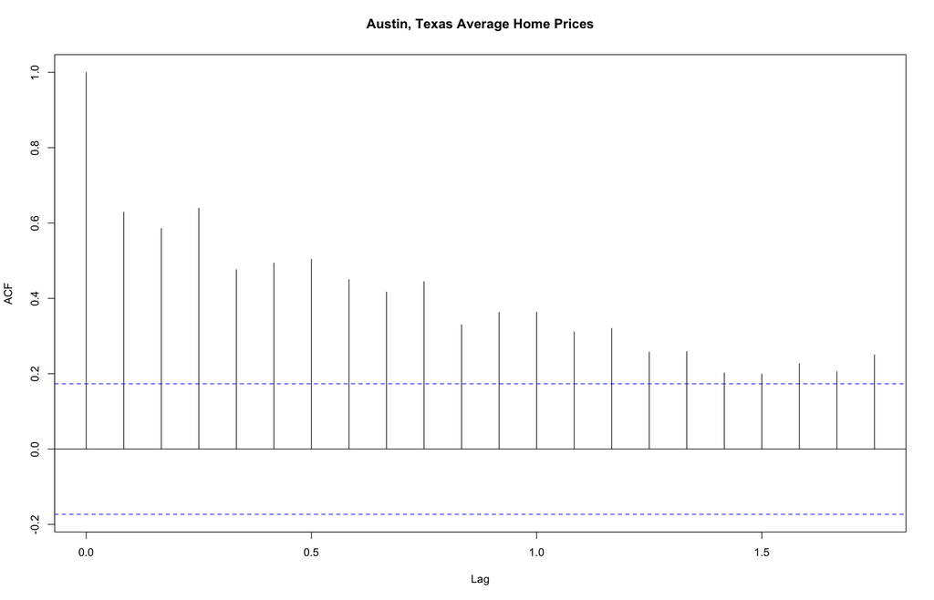

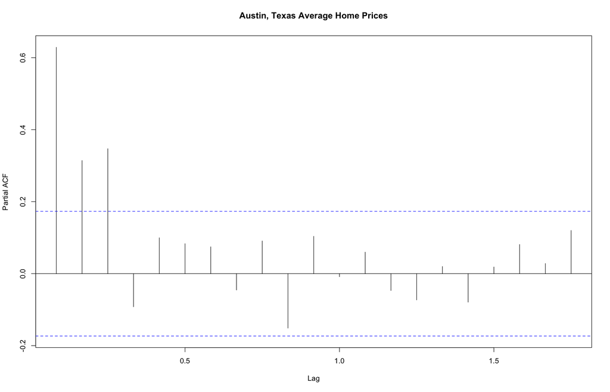

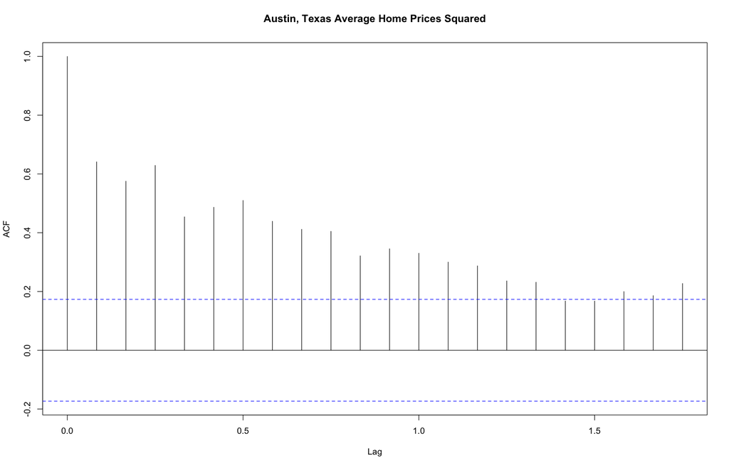

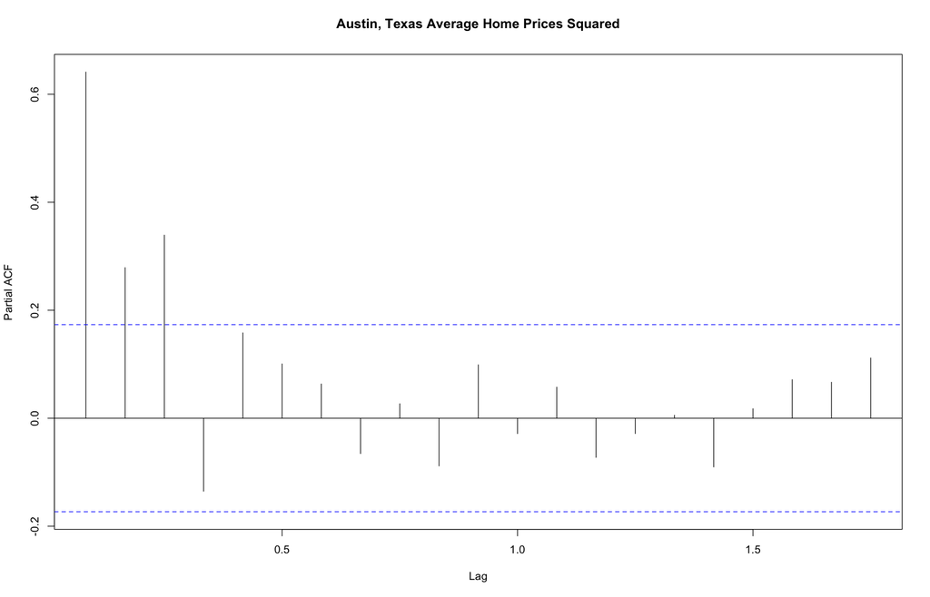

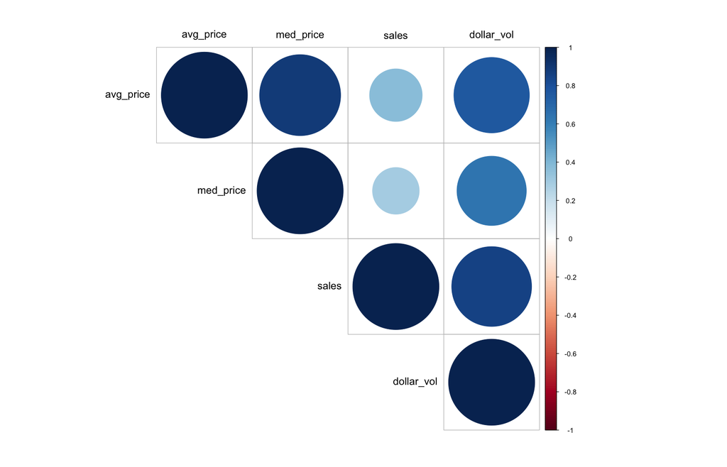

```r
# plotting decomposed time series of austin, tx
austin_decomposed <- decompose(austin_ts, type = 'multiplicative')
autoplot(austin_decomposed) +
labs(x = 'Year Since 2011',
     title = 'Decomposition of Austin, Texas Average Home Prices')

# plotting acf of austin, tx
acf(austin_ts, main = 'Austin, Texas Average Home Prices')

# plotting pacf of austin, tx
pacf(austin_ts, main = 'Austin, Texas Average Home Prices')

# plotting acf of squared observations
acf(austin_ts ^ 2, main = 'Austin, Texas Average Home Prices Squared')

# plotting pacf of squared observations
pacf(austin_ts ^ 2, main = 'Austin, Texas Average Home Prices Squared')



# plotting correlation of features
austin_feats <- df %>%
filter(county == 'Austin') %>%
select(c('sales', 'dollar_vol', 'avg_price', 'med_price'))

corr_figs <- cor(austin_feats)
par(xpd = TRUE)
corrplot(corr_figs,
         type = 'upper',
         order = 'hclust',
         tl.col = 'black',
         tl.srt = 0.0,
         tl.offset = 0.6,
         tl.cex = 1.2,
         mar = c(2, 3, 3, 3))
```

The proposed model is then:

$$y_t=\sqrt{a_0+a_1\sigma^2_{t-1}}\epsilon_t$$

which intuitively is what we'd expect - the recent home price volatility dominates the forecast for the following observation. Now, the question is how exactly do we estimate $a_0$ and $a_1$? Well, we can try 1) the MLE and 2) bayesian bs.

# Sources

- "Applied Optimal Estimation" - Arthur Gelb
  - Graduate level book on dynamics; only for the mathematically inclined ;)
- "An Introduction to Sequential Monte Carlo" - Chopin and Papaspiliopoulos
  - Modern book on applications; garbage reference for basic time series, but good applications
- "Introduction to Time Series and Forecasting" - Brockwell and Davis
  - Good undergraduate book on time series

MIT State Space and Control

- https://ocw.mit.edu/courses/aeronautics-and-astronautics/16-30-feedback-control-systems-fall-2010/lecture-notes/MIT16_30F10_lec05.pdf

Duke Good Reference on AR and MA processes

- https://people.duke.edu/~rnau/411arim3.htm#plots

Online Time Series Book - good code examples I guess

- https://otexts.com/fpp2/index.html

Cool Library on Probabilistic Modelling:

- http://edwardlib.org

Engineering Oriented Approach to Filtering and State-Space:

- https://www.dsprelated.com/freebooks/filters/State_Space_Filters.html